# 相關、迴歸與結果解讀

## 迴歸線有方向

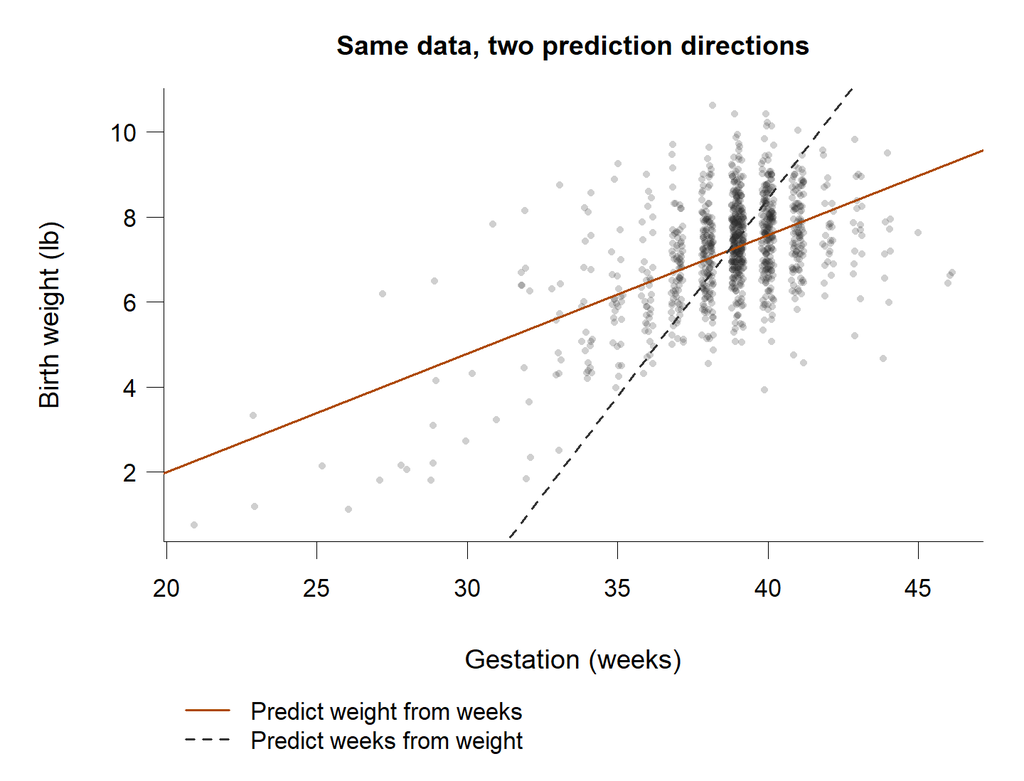

橘色實線預測體重，灰色虛線預測週數；交換角色會改變最小化的誤差。

- 改用 y 預測 x，就最小化 x 的誤差。反向斜率是 $r \cdot s_x / s_y$，不是原斜率的倒數。

| 模型 | 斜率 |
| --- | --- |
| 體重 ~ 週數 | 0.279 磅／週 |
| 週數 ~ 體重 | 1.076 週／磅 |

- 兩者的 r 都是 0.548。

births14

## 練習｜肩圍能預測身高多少？

- 507 名身體活躍者；x 是肩圍，y 是身高（均為 cm），r = 0.67。

|  | 平均 | SD |
| --- | --- | --- |
| 肩圍 x | 107.20 | 10.37 |
| 身高 y | 171.14 | 9.41 |

- 寫出身高的最小平方線，解讀斜率與截距；算出 R² 並說明其意義。
- $b_1=0.67(9.41/10.37)\approx0.608$；$b_0\approx105.97$。
- $\hat y=105.97+0.608x$。肩圍多 1 cm，預測平均身高多 0.608 cm；0 cm 肩圍的截距沒有實際意義。
- **R² = 0.4489**：樣本內身高變異約 45% 可由肩圍的線性關係說明。

IMS 2e §7.5，Exercise 7.22 a–c（Body measurements, regression）

## 練習｜預測、殘差與外插

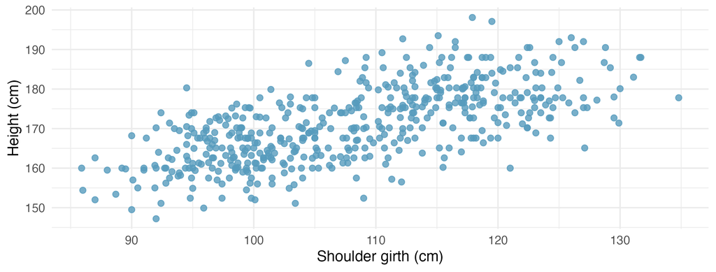

橫軸肩圍、縱軸身高，均為 cm；56 cm 肩圍落在圖外。

- $\hat y=105.97+0.608x$（cm）。
- 學生肩圍 100 cm、身高 160 cm。預測與殘差是多少？能用這條線預測肩圍 56 cm 的一歲幼兒嗎？
- 預測約 **166.76 cm**；殘差約 **−6.76 cm**，模型高估（若用顯示的係數：166.77、−6.77 cm）。
- 有兩個限制：**範圍外**與**研究對象不同**。不能只代入 56 cm 就宣稱適用。

IMS 2e §7.5，Exercise 7.22 d–f（CC BY-SA）

## 練習 3｜孕期體重增加

- 以母親孕期體重增加（磅）預測出生體重（磅）：
- ŷ = 6.83 + 0.0124 × 增加量（n = 958，R² = 0.022）
- 用一句話解讀斜率。為什麼不能寫成「孕期多胖 10 磅，寶寶會重 0.12 磅」？
- 孕期體重增加多 1 磅的母親，其新生兒平均出生體重約多 0.012 磅。
- 後一種寫法把不同母親之間的比較，說成同一位母親改變後的因果效果；這是觀察資料。

births14；本課程

## 為何用平均數當預測基準？

- 若每個人都預測同一個常數 c，怎麼選才能讓平方誤差最小？
- 總平方和（total sum of squares，SST）：每個 y 到平均 y 的距離平方和。

$$\begin{aligned}\sum_i(y_i-c)^2 &= \underbrace{\sum_i(y_i-\bar y)^2}_{\mathrm{SST}}\\ &\quad+n(c-\bar y)^2\end{aligned}$$

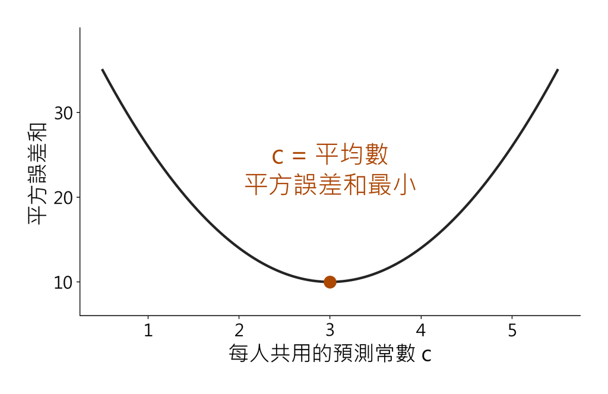

示意值 1、2、4、5：曲線最低點位於平均數。非 Elmhurst 資料。

- SST 固定，第二項不會小於 0；**c = 平均數**時，第二項為 0。
- 因此 R² 比較的是最佳常數預測與最小平方直線，兩者必須使用同一批 y。

IMS 2e §7.2.5

## 比較兩種平方誤差：SST 與 SSE

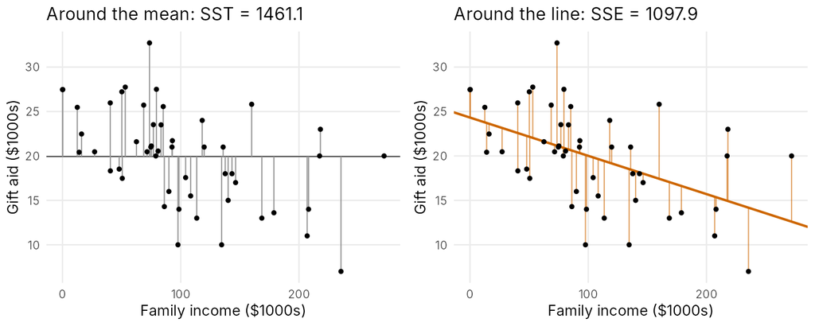

左圖以平均助學金為基準，右圖改用迴歸線；垂直線段表示各筆誤差。

- 同一批學生：改用收入預測後，平方誤差和由約 1461 降到 1098。

IMS 2e §7.2.5；openintro elmhurst

## R²：比平均數基準改善多少？

| 基準 | 平方誤差和 |
| --- | --- |
| 每人都預測平均 y | SST：$\sum_i(y_i-\bar y)^2$ |
| 用 x 的直線預測 y | SSE：$\sum_i(y_i-\hat y_i)^2$ |

$$R^2=\frac{\mathrm{SST}-\mathrm{SSE}}{\mathrm{SST}}
=1-\frac{1098}{1461}\approx0.25$$

- 同一批學生，改用家庭收入的直線後，**平方誤差和減少約 25%**。
- 其餘約 75% 是模型尚未說明的殘差變異，不能直接分配給特定原因。

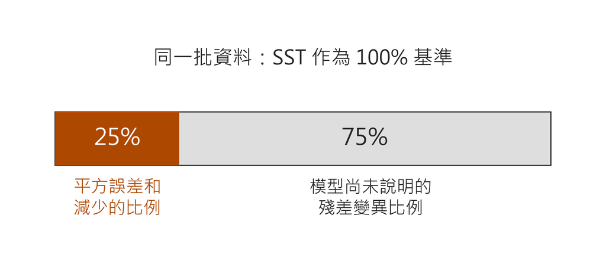

整條代表同一批資料的 SST；橘色約 25% 是平方誤差和減少的比例，灰色約 75% 是剩餘比例。

IMS 2e §7.2.5；openintro elmhurst、births14

## R² 的解讀有前提

| 說法 | 正確嗎？ |
| --- | --- |
| R² = 0.30：30% 的新生兒被預測正確 | 錯，R² 是變異的比例 |
| R² 小，斜率就不重要 | 錯，足月 R² = 0.035，斜率是否重要看研究脈絡 |
| R² 大，直線就合適 | 錯，彎曲的關係也可能有不低的 R² |
| 同一批資料、含截距的單一變項最小平方迴歸：R² = r² | 對，Elmhurst：(−0.499)² ≈ 0.25；不能任意外推到其他模型 |

- R² 沒有正負號，不能告訴你 y 隨 x 上升或下降；它也不能表示因果效果，或保證新個案的預測準確。

IMS 2e §7.2.5；births14

## 練習 4｜反向斜率為何不是倒數？

- 自編情境：r = 0.6、s_x = 8、s_y = 12。由 $b_1=r s_y/s_x$：

| 預測方向 | 斜率 | 乘積 |
| --- | --- | --- |
| x → y | $0.6\times12/8=0.9$ | ？ |
| y → x | $0.6\times8/12=0.4$ |  |

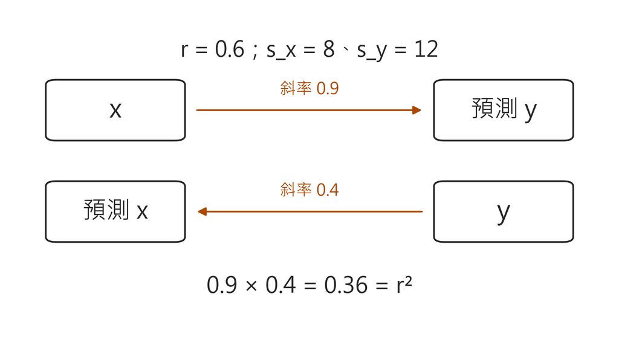

預測方向相反，斜率乘積是 r²；只有 |r| = 1 時，兩個斜率才互為倒數。

- 兩斜率乘積 **0.36 = r²**；本例的 R² 也是 0.36。
- 要互為倒數，乘積必須是 1，也就是 $|r|=1$。單位相反，不代表數值互為倒數。

IMS 2e §7.2.3、§7.2.5

## 整合：四個數字

|  | Pearson r | Spearman r_s | 斜率 b₁ | R² |
| --- | --- | --- | --- | --- |
| 回答 | 線性關聯的方向與強度 | 單調關聯的方向與強度 | x 多一單位，y 平均預測差多少 | 相對平均數基準的平方誤差改善比例 |
| 單位 | 無 | 無 | y 單位／x 單位 | 無（0–1） |
| 對調 x、y | 不變 | 不變 | 改變 | 不變 |
| 對極端點 | 可能敏感 | 較不敏感，仍可能改變 | 可能敏感 | 可能敏感 |

- 同一批資料、含截距的單一變項最小平方迴歸中，交換 x、y 不改變 R²；但預測目標改變，兩個方向的斜率通常也不同。

IMS 2e §7.1–7.2；Rosner 8e §11.12

## 結論要回答原來的問題

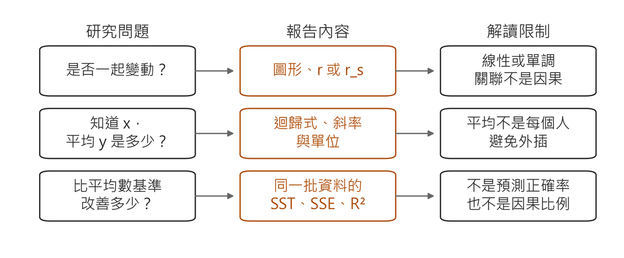

每一列把研究問題連到相應的報告內容，再連到解讀限制。

- 相關結論要說明是線性還是單調；迴歸結論要寫出預測誰、斜率單位與適用範圍。兩者都不能只靠觀察資料判定因果。

IMS 2e §7.1–7.2

## 練習 5｜選方法、解讀結果與限制

- 該描述相關、配適迴歸，還是不能直接用既有直線？
1. 50 名成人各量一次收縮壓與舒張壓，想知道兩者是否一起升降
2. 用年齡預測 50 名成人的平均收縮壓
3. 用 20–60 歲成人的直線，預測 5 歲幼童的平均收縮壓
- A：**相關**，兩者地位對等；看形狀選 Pearson 或 Spearman。
- B：**迴歸**，斜率單位 mmHg／歲，搭配 R²；平均預測不是個別結果，觀察資料不寫成因果。殘差檢查可回顧 Week 6 Part 1。
- C：**不能直接套用**。5 歲在資料範圍外，研究對象也從成人改成幼童；算得出不等於適用。

本課程；IMS 2e §7.1–7.2、§7.2.4

## Slido｜Week 7 Part 1

Week 7 Part 1｜概念題 1–3，單選，每題 45 秒。

[**點此開啟 Slido 作答頁 ↗**](https://app.sli.do/event/x5omQqchQREmC2wRNXaHha) · 活動代碼 **2244010**

[figure not shown]

[Week 7 Slido](https://app.sli.do/event/x5omQqchQREmC2wRNXaHha)